# NLP Case study 1

# MECE - Task and Assignments

| Task Number | Description | Assigned To |
| --- | --- | --- |
| Q1 | Naive Bayes model using Count Vectors for Unigram | Maaz |
| Q2 | SVM model using TF-IDF Vectors with Unigram+Bigram | Isha and Vandit |
| Q3 | Naive Bayes model using TF-IDF Vectors for Unigram+Bigram | Rutul |
| Q4 | SVM model using Count Vectors for Unigram+Bigram | Tirth and Mayisha |
| Q5 | Naive Bayes model using One-Hot Vectors with Unigram+Bigram | Urjeeth and Devendra |

## NB model with Unigram+CountVectors - Maaz

**Config of the model trained**

**Training Data Check**

Confusion Matrix Built - Yes

F1 Score for Positive = 0.9249

F1 Score for Negative = 0.7760

AUC plotted - Yes

AUC = 0.9477

Accuracy computed - Yes

Accuracy = 0.8541

**Feature Engg**

Categorical/Numerical Features Added - Yes

Name 2 features added - sentiment score,scaled_sentiment_score

Cross Validation - Yes (0.80)

**Interpretability**

Interpretability Implemented? - Yes, Local

2 interesting findings?

-world cloud for positive and negative reviews

**Testing Data Check**

Confusion Matrix Built - Yes

F1 Score for Positive = 0.8964

F1 Score for Negative = 0.7340

AUC plotted - Yes

AUC = 0.9047

Accuracy computed - Yes

Accuracy = 0.8065

## Prompts

**read the csv file and i want to Build the following models to predict whether a given review is Positive (4 or 5 stars), Negative (2 or less stars) or Neutral on the Yelp Dataset**

1. Naive Bayes model using Count Vectors for Unigram

**I have to clean the data before building the model like converting into lower case, removing punctuation, removing stop words and digits**

**Read the .ipynb file. I have build Naive Bayes model using Count Vectors for Unigram. my model is not performing well due to class imbalance and here are my results**

F1 Score for Positive (Train): 0.9249 F1 Score for Negative (Train): 0.7760 F1 Score for Neutral (Train): 0.5758

F1 Score for Positive (Test): 0.8964 F1 Score for Negative (Test): 0.7340 F1 Score for Neutral (Test): 0.3653

**explain the steps to add new features and tune my model to improve it?**

## 1. Naive Bayes model using Count Vectors for Unigram

**Build the following models to predict whether a given review is Positive (4 or 5 stars), Negative (2 or less stars) or Neutral on the Yelp Dataset**

```python
# import all necessary libraries

import pandas as pd
import numpy as np
import pandas as pd
import re
import string
from nltk.corpus import stopwords
from nltk.tokenize import word_tokenize
from nltk.stem import PorterStemmer, WordNetLemmatizer
from sklearn.feature_extraction.text import CountVectorizer
from sklearn.model_selection import train_test_split
from sklearn.naive_bayes import MultinomialNB
from sklearn.metrics import classification_report, accuracy_score, confusion_matrix
import time
from sklearn.metrics import f1_score, roc_auc_score
import matplotlib.pyplot as plt
import matplotlib.pyplot as plt
from sklearn.metrics import roc_curve, auc

# Download necessary NLTK data
import nltk
nltk.download('punkt')
nltk.download('stopwords')
nltk.download('wordnet')
```

```
True
```

```python
# To display all the text

pd.set_option('display.max_colwidth', None)
pd.set_option('display.max_rows', None)
pd.set_option('display.max_columns', None)
```

```python
## import sample dataset

df = pd.read_csv('yelp_sample_20k.csv')

## display top 5 rows

df.head()
```

|  | text | stars |
| --- | --- | --- |
| 0 | We really enjoyed their use of homemade ingredients! Really great meals. A new favorite spot! | 5.0 |
| 1 | We moved to Sarasota and upon many recommendations decided to go to Tampa to buy furniture. Modani was the store everyone suggested and we were not disappointed.\nJen was fun as well as very professio… | 5.0 |
| 2 | Very disappointed in today's meal. The wife and both got a pasta dish. Both were watered downed and had little to no flavor. My dish was a shrimp and chicken pasta. Had 1 piece of shrimp buried in pas… | 2.0 |
| 3 | I wish I could reward the store w 5 stars, product with 4 to 5, and the marketing one star! Great service in this location both times I've been (new to AZ). Love the panties. Do not understand the rat… | 4.0 |
| 4 | Came here for brunch yesterday, it goes till 3pm which is great if you are a late riser. We sat at the bar and Angelo was our bartender. Love coming here for brunch and have many times. Normally get t… | 5.0 |

```python
# To check the shape of the dataset
df.shape
```

```
(20000, 2)
```

```python
def assign_sentiment(stars):
    if stars >= 4:
        return 'Positive'
    elif stars <= 2:
        return 'Negative'
    else:
        return 'Neutral'

df['sentiment'] = df['stars'].apply(assign_sentiment)
```

```python
df.head()
```

|  | text | stars | sentiment |
| --- | --- | --- | --- |
| 0 | We really enjoyed their use of homemade ingredients! Really great meals. A new favorite spot! | 5.0 | Positive |
| 1 | We moved to Sarasota and upon many recommendations decided to go to Tampa to buy furniture. Modani was the store everyone suggested and we were not disappointed.\nJen was fun as well as very professio… | 5.0 | Positive |
| 2 | Very disappointed in today's meal. The wife and both got a pasta dish. Both were watered downed and had little to no flavor. My dish was a shrimp and chicken pasta. Had 1 piece of shrimp buried in pas… | 2.0 | Negative |
| 3 | I wish I could reward the store w 5 stars, product with 4 to 5, and the marketing one star! Great service in this location both times I've been (new to AZ). Love the panties. Do not understand the rat… | 4.0 | Positive |
| 4 | Came here for brunch yesterday, it goes till 3pm which is great if you are a late riser. We sat at the bar and Angelo was our bartender. Love coming here for brunch and have many times. Normally get t… | 5.0 | Positive |

## Text Cleaning

```python
# Convert to lowercase
def to_lowercase(text):
    return text.lower()

# Remove punctuation
def remove_punctuation(text):
    return text.translate(str.maketrans('', '', string.punctuation))

# Remove stop words
stop_words = set(stopwords.words('english'))
def remove_stopwords(text):
    tokens = word_tokenize(text)
    return ' '.join([word for word in tokens if word not in stop_words])

# Remove digits
def remove_digits(text):
    return re.sub(r'\d+', '', text)

# Tokenize text
def tokenize_text(text):
    return word_tokenize(text)

# Lemmatization
lemmatizer = WordNetLemmatizer()
def apply_lemmatization(text):
    tokens = word_tokenize(text)
    return ' '.join([lemmatizer.lemmatize(word) for word in tokens])
```

```python
#import nltk
#nltk.download('punkt_tab')
```

```python
# Apply cleaning functions
df['cleaned_text'] = df['text'].apply(to_lowercase)\
                               .apply(remove_punctuation)\
                               .apply(remove_digits)\
                               .apply(remove_stopwords)\
                               .apply(apply_lemmatization)
```

```python
df.head()
```

|  | text | stars | sentiment | cleaned_text |
| --- | --- | --- | --- | --- |
| 0 | We really enjoyed their use of homemade ingredients! Really great meals. A new favorite spot! | 5.0 | Positive | really enjoyed use homemade ingredient really great meal new favorite spot |
| 1 | We moved to Sarasota and upon many recommendations decided to go to Tampa to buy furniture. Modani was the store everyone suggested and we were not disappointed.\nJen was fun as well as very professio… | 5.0 | Positive | moved sarasota upon many recommendation decided go tampa buy furniture modani store everyone suggested disappointed jen fun well professional work ordered needed subsequently cancel item problem first… |
| 2 | Very disappointed in today's meal. The wife and both got a pasta dish. Both were watered downed and had little to no flavor. My dish was a shrimp and chicken pasta. Had 1 piece of shrimp buried in pas… | 2.0 | Negative | disappointed today meal wife got pasta dish watered downed little flavor dish shrimp chicken pasta piece shrimp buried pasta tail still coming two year time disappointed |
| 3 | I wish I could reward the store w 5 stars, product with 4 to 5, and the marketing one star! Great service in this location both times I've been (new to AZ). Love the panties. Do not understand the rat… | 4.0 | Positive | wish could reward store w star product marketing one star great service location time ive new az love panty understand rationale online labor day deal complete w signage store associate explain doesnt… |
| 4 | Came here for brunch yesterday, it goes till 3pm which is great if you are a late riser. We sat at the bar and Angelo was our bartender. Love coming here for brunch and have many times. Normally get t… | 5.0 | Positive | came brunch yesterday go till pm great late riser sat bar angelo bartender love coming brunch many time normally get thing changed brunch menu since last really missed egg benedict longer new menu get… |

```python
# Assign features (cleaned text) and target (sentiment)
X = df['cleaned_text']  # Preprocessed text
y = df['sentiment']     # Sentiment (Positive, Negative, Neutral)

# Split into training and testing sets
X_train, X_test, y_train, y_test = train_test_split(X, y, test_size=0.3, random_state=42)
```

### Training Time

```python
# Start time to measure training duration
start_time = time.time()

# Initialize CountVectorizer for Unigram
vectorizer = CountVectorizer(ngram_range=(1, 1),max_features=10000)  # Unigram

# Transform the text into Count Vectors
X_train_vectors = vectorizer.fit_transform(X_train)
X_test_vectors = vectorizer.transform(X_test)

# Initialize the Multinomial Naive Bayes model
nb_model = MultinomialNB()

# Train the model
nb_model.fit(X_train_vectors, y_train)

# Measure training time
train_time = time.time() - start_time
print(f"Training Time: {train_time:.2f} seconds")
```

```
Training Time: 0.28 seconds
```

```python
# Make predictions on the test set
y_pred = nb_model.predict(X_test_vectors)

# Evaluate the model
print("Classification Report:\n", classification_report(y_test, y_pred))
print("Accuracy Score:", accuracy_score(y_test, y_pred))
print("Confusion Matrix:\n", confusion_matrix(y_test, y_pred))
```

```
Classification Report:
               precision    recall  f1-score   support

    Negative       0.73      0.74      0.73      1385
     Neutral       0.34      0.39      0.37       551
    Positive       0.91      0.89      0.90      4064

    accuracy                           0.81      6000
   macro avg       0.66      0.67      0.67      6000
weighted avg       0.81      0.81      0.81      6000

Accuracy Score: 0.8063333333333333
Confusion Matrix:
 [[1026  223  136]
 [ 106  215  230]
 [ 278  189 3597]]
```

## Example new review

```python
new_reviews = ["I love this place!"]
# Preprocess and transform new reviews
new_reviews_vectors = vectorizer.transform(new_reviews)

# Predict sentiment
new_predictions = nb_model.predict(new_reviews_vectors)

print(new_predictions)  # Output: ['Positive', 'Negative', 'Neutral']
```

```
['Positive']
```

## Training data check and Evaluation

```python
from sklearn.metrics import accuracy_score

# Predict the class labels for training data
y_train_pred = nb_model.predict(X_train_vectors)
y_test_pred = nb_model.predict(X_test_vectors)

# Calculate accuracy for both training and testing data
accuracy_train = accuracy_score(y_train, y_train_pred)
accuracy_test = accuracy_score(y_test, y_test_pred)

# Print the accuracy scores
print(f"Accuracy Score (Train): {accuracy_train:.4f}")
print(f"Accuracy Score (Test): {accuracy_test:.4f}")
```

```
Accuracy Score (Train): 0.8542
Accuracy Score (Test): 0.8063
```

```python
# Compute F1 Score for all classes
f1_train = f1_score(y_train, y_train_pred, average='weighted')
print(f"Weighted F1 Score (Train): {f1_train:.4f}")
```

```
Weighted F1 Score (Train): 0.8575
```

```python
f1_pos_train = f1_score(y_train, y_train_pred, labels=['Positive'], average='macro')
f1_neg_train = f1_score(y_train, y_train_pred, labels=['Negative'], average='macro')
f1_neu_train = f1_score(y_train, y_train_pred, labels=['Neutral'], average='macro')

print(f"F1 Score for Positive (Train): {f1_pos_train:.4f}")
print(f"F1 Score for Negative (Train): {f1_neg_train:.4f}")
print(f"F1 Score for Neutral (Train): {f1_neu_train:.4f}")
```

```
F1 Score for Positive (Train): 0.9250
F1 Score for Negative (Train): 0.7756
F1 Score for Neutral (Train): 0.5759
```

```python
# Get predicted probabilities for all classes
y_train_prob = nb_model.predict_proba(X_train_vectors)

# Compute AUC for each class using 'ovr' or 'ovo'
auc_train = roc_auc_score(y_train, y_train_prob, multi_class='ovr', average='weighted')
print(f"AUC Score (Train): {auc_train:.4f}")
```

```
AUC Score (Train): 0.9478
```

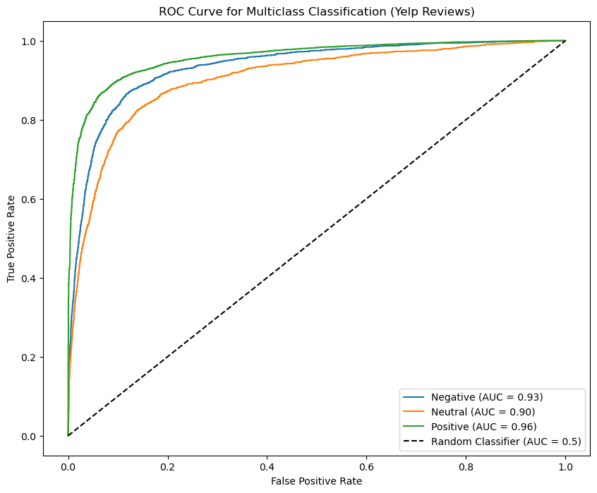

```python
# Get predicted probabilities for each class
y_train_prob = nb_model.predict_proba(X_train_vectors)

# Map classes to indices: Assuming 0=Negative, 1=Neutral, 2=Positive
class_labels = ['Negative', 'Neutral', 'Positive']

# Initialize the plot
plt.figure(figsize=(10, 8))

# Loop through each class and compute ROC curve
for i, label in enumerate(class_labels):
    # Compute the ROC curve for each class
    fpr, tpr, _ = roc_curve(y_train == label, y_train_prob[:, i])

    # Compute AUC for the class
    auc_score = auc(fpr, tpr)

    # Plot ROC curve
    plt.plot(fpr, tpr, label=f'{label} (AUC = {auc_score:.2f})')

# Plot the diagonal line (random classifier)
plt.plot([0, 1], [0, 1], 'k--', label='Random Classifier (AUC = 0.5)')

# Labels and title
plt.xlabel('False Positive Rate')
plt.ylabel('True Positive Rate')
plt.title('ROC Curve for Multiclass Classification (Yelp Reviews)')
plt.legend(loc='lower right')

# Show the plot
plt.show()
```

### Testing Data Check and Evaluation

```python
# Compute F1 Score for all classes
f1_test = f1_score(y_test, y_pred, average='weighted')
print(f"Weighted F1 Score (Test): {f1_test:.4f}")
```

```
Weighted F1 Score (Test): 0.8100
```

```python
f1_pos_test = f1_score(y_test, y_pred, labels=['Positive'], average='macro')
f1_neg_test = f1_score(y_test, y_pred, labels=['Negative'], average='macro')
f1_neu_test = f1_score(y_test, y_pred, labels=['Neutral'], average='macro')

print(f"F1 Score for Positive (Test): {f1_pos_test:.4f}")
print(f"F1 Score for Negative (Test): {f1_neg_test:.4f}")
print(f"F1 Score for Neutral (Test): {f1_neu_test:.4f}")
```

```
F1 Score for Positive (Test): 0.8962
F1 Score for Negative (Test): 0.7342
F1 Score for Neutral (Test): 0.3650
```

```python
# Get predicted probabilities for all classes
y_test_prob = nb_model.predict_proba(X_test_vectors)

# Compute AUC for each class using 'ovr' or 'ovo'
auc_test = roc_auc_score(y_test, y_test_prob, multi_class='ovr', average='weighted')
print(f"AUC Score (Test): {auc_test:.4f}")
```

```
AUC Score (Test): 0.9047
```

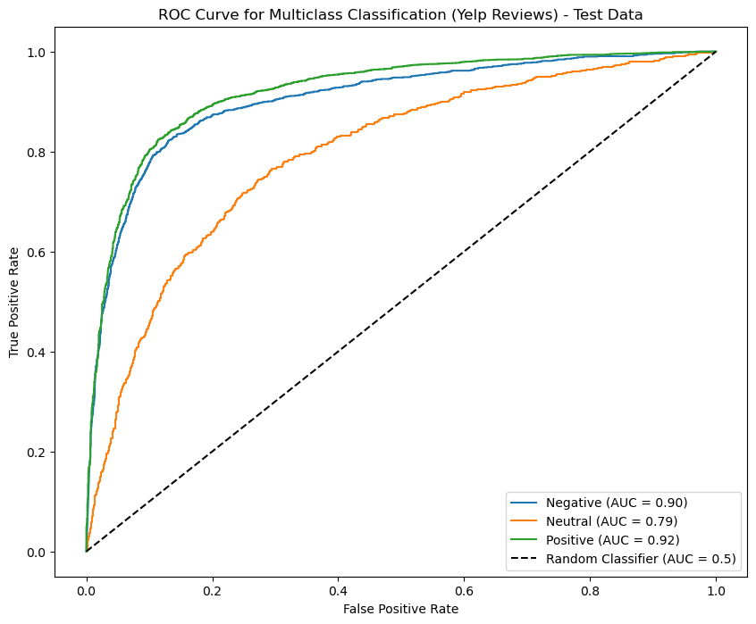

```python
# Get predicted probabilities for testing data
y_test_prob = nb_model.predict_proba(X_test_vectors)

# Initialize the plot
plt.figure(figsize=(10, 8))

# Loop through each class and compute ROC curve
for i, label in enumerate(class_labels):
    # Compute the ROC curve for each class
    fpr, tpr, _ = roc_curve(y_test == label, y_test_prob[:, i])

    # Compute AUC for the class
    auc_score = auc(fpr, tpr)

    # Plot ROC curve
    plt.plot(fpr, tpr, label=f'{label} (AUC = {auc_score:.2f})')

# Plot the diagonal line (random classifier)
plt.plot([0, 1], [0, 1], 'k--', label='Random Classifier (AUC = 0.5)')

# Labels and title
plt.xlabel('False Positive Rate')
plt.ylabel('True Positive Rate')
plt.title('ROC Curve for Multiclass Classification (Yelp Reviews) - Test Data')
plt.legend(loc='lower right')

# Show the plot
plt.show()
```

**Our dataset has an imbalance in sentiment distribution, especially with the Neutral class being underrepresented**

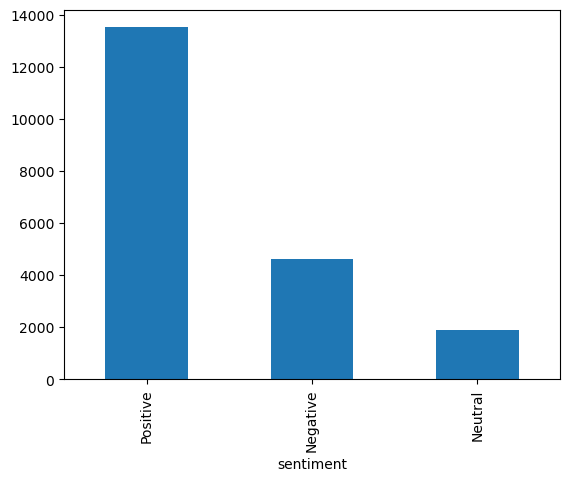

```python
df['sentiment'].value_counts().plot(kind = 'bar')
```

## Model Improvement

**I will be implementing the following task to improve the model:**

**Handling Class Imbalance using SMOTE**

**Feature Engineering with TF-IDF, and sentiment scores**

**Hyperparameter Tuning for Naive Bayes**

**I have added sentiment score as a new feature - It helps in capturing the overall sentiment beyond just words**

**I have added one more feature - scaled_sentiment_score just to ensure it has numerical consistency with TD-IDF**

```python
from imblearn.over_sampling import SMOTE
from nltk.sentiment import SentimentIntensityAnalyzer
from sklearn.preprocessing import MinMaxScaler
from sklearn.feature_extraction.text import TfidfVectorizer
from scipy.sparse import hstack
```

```python
# Add Sentiment Scores
sia = SentimentIntensityAnalyzer()
df['sentiment_score'] = df['text'].apply(lambda x: sia.polarity_scores(x)['compound'])

# Scale sentiment scores to be non-negative
scaler = MinMaxScaler(feature_range=(0, 1))
df['scaled_sentiment_score'] = scaler.fit_transform(df[['sentiment_score']])

# Vectorization using TF-IDF with limited features
tfidf = TfidfVectorizer(ngram_range=(1,1), max_features=5000)
X_text = tfidf.fit_transform(df['cleaned_text'])
X_features = hstack([X_text, np.array(df[['scaled_sentiment_score']])])
y = df['sentiment']

# Train-Test Split
X_train, X_test, y_train, y_test = train_test_split(X_features, y, test_size=0.3, random_state=42, stratify=y)

# Handle Class Imbalance using SMOTE (Synthetic Minority Over-sampling Technique)
smote = SMOTE(random_state=42)
X_train_resampled, y_train_resampled = smote.fit_resample(X_train, y_train)
```

```python
df.head()
```

|  | text | stars | sentiment | cleaned_text | sentiment_score | scaled_sentiment_score |
| --- | --- | --- | --- | --- | --- | --- |
| 0 | We really enjoyed their use of homemade ingredients! Really great meals. A new favorite spot! | 5.0 | Positive | really enjoyed use homemade ingredient really great meal new favorite spot | 0.9113 | 0.955686 |
| 1 | We moved to Sarasota and upon many recommendations decided to go to Tampa to buy furniture. Modani was the store everyone suggested and we were not disappointed.\nJen was fun as well as very professio… | 5.0 | Positive | moved sarasota upon many recommendation decided go tampa buy furniture modani store everyone suggested disappointed jen fun well professional work ordered needed subsequently cancel item problem first… | 0.6879 | 0.843824 |
| 2 | Very disappointed in today's meal. The wife and both got a pasta dish. Both were watered downed and had little to no flavor. My dish was a shrimp and chicken pasta. Had 1 piece of shrimp buried in pas… | 2.0 | Negative | disappointed today meal wife got pasta dish watered downed little flavor dish shrimp chicken pasta piece shrimp buried pasta tail still coming two year time disappointed | -0.8275 | 0.085023 |
| 3 | I wish I could reward the store w 5 stars, product with 4 to 5, and the marketing one star! Great service in this location both times I've been (new to AZ). Love the panties. Do not understand the rat… | 4.0 | Positive | wish could reward store w star product marketing one star great service location time ive new az love panty understand rationale online labor day deal complete w signage store associate explain doesnt… | 0.7386 | 0.869210 |
| 4 | Came here for brunch yesterday, it goes till 3pm which is great if you are a late riser. We sat at the bar and Angelo was our bartender. Love coming here for brunch and have many times. Normally get t… | 5.0 | Positive | came brunch yesterday go till pm great late riser sat bar angelo bartender love coming brunch many time normally get thing changed brunch menu since last really missed egg benedict longer new menu get… | 0.9980 | 0.999099 |

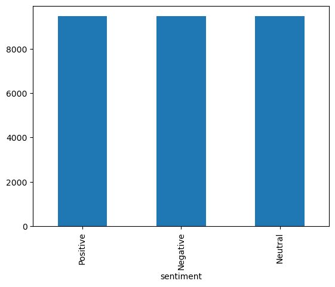

```python
y_train_resampled.value_counts().plot(kind = 'bar')
```

```python
# Start time to measure training duration
start_time = time.time()

# Initialize the Multinomial Naive Bayes model
nb_model = MultinomialNB()

# Train the model
nb_model.fit(X_train_resampled, y_train_resampled)

# Measure training time
train_time = time.time() - start_time
print(f"Training Time: {train_time:.2f} seconds")
```

```
Training Time: 0.05 seconds
```

```python
# Make predictions on the test set
y_pred = nb_model.predict(X_test)

# Evaluate the model
print("Classification Report:\n", classification_report(y_test, y_pred))
print("Accuracy Score:", accuracy_score(y_test, y_pred))
print("Confusion Matrix:\n", confusion_matrix(y_test, y_pred))
```

```
Classification Report:
               precision    recall  f1-score   support

    Negative       0.73      0.73      0.73      1380
     Neutral       0.28      0.63      0.38       565
    Positive       0.95      0.78      0.86      4055

    accuracy                           0.76      6000
   macro avg       0.65      0.71      0.66      6000
weighted avg       0.84      0.76      0.79      6000

Accuracy Score: 0.7566666666666667
Confusion Matrix:
 [[1001  333   46]
 [  93  356  116]
 [ 270  602 3183]]
```

```python
from sklearn.metrics import accuracy_score

# Predict the class labels for training data
y_train_pred = nb_model.predict(X_train_resampled)
y_test_pred = nb_model.predict(X_test)

# Calculate accuracy for both training and testing data
accuracy_train = accuracy_score(y_train_resampled, y_train_pred)
accuracy_test = accuracy_score(y_test, y_test_pred)

# Print the accuracy scores
print(f"Accuracy Score (Train): {accuracy_train:.4f}")
print(f"Accuracy Score (Test): {accuracy_test:.4f}")
```

```
Accuracy Score (Train): 0.8288
Accuracy Score (Test): 0.7567
```

```python
# Compute F1 Score for all classes
f1_train = f1_score(y_train_resampled, y_train_pred, average='weighted')
print(f"Weighted F1 Score (Train): {f1_train:.4f}")
```

```
Weighted F1 Score (Train): 0.8305
```

```python
f1_pos_train = f1_score(y_train_resampled, y_train_pred, labels=['Positive'], average='macro')
f1_neg_train = f1_score(y_train_resampled, y_train_pred, labels=['Negative'], average='macro')
f1_neu_train = f1_score(y_train_resampled, y_train_pred, labels=['Neutral'], average='macro')

print(f"F1 Score for Positive (Train): {f1_pos_train:.4f}")
print(f"F1 Score for Negative (Train): {f1_neg_train:.4f}")
print(f"F1 Score for Neutral (Train): {f1_neu_train:.4f}")
```

```
F1 Score for Positive (Train): 0.8679
F1 Score for Negative (Train): 0.8243
F1 Score for Neutral (Train): 0.7992
```

```python
# Get predicted probabilities for all classes
y_train_prob = nb_model.predict_proba(X_train_resampled)

# Compute AUC for each class using 'ovr' or 'ovo'
auc_train = roc_auc_score(y_train_resampled, y_train_prob, multi_class='ovr', average='weighted')
print(f"AUC Score (Train): {auc_train:.4f}")
```

```
AUC Score (Train): 0.9509
```

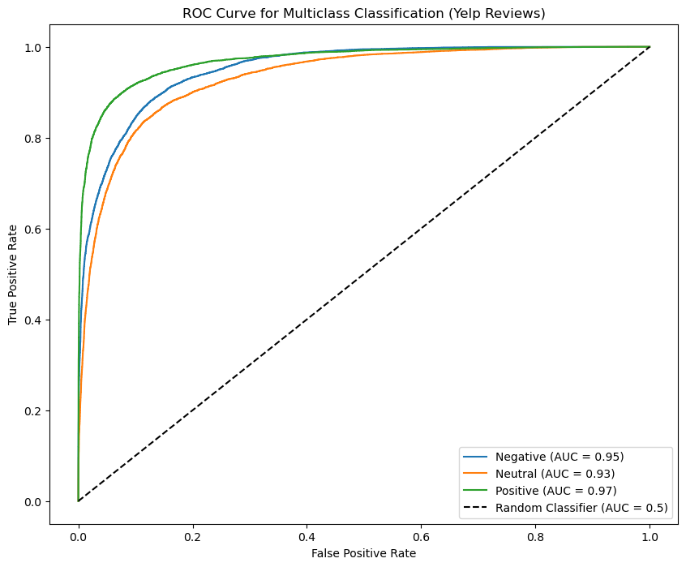

```python
# Get predicted probabilities for each class
y_train_prob = nb_model.predict_proba(X_train_resampled)

# Map classes to indices: Assuming 0=Negative, 1=Neutral, 2=Positive
class_labels = ['Negative', 'Neutral', 'Positive']

# Initialize the plot
plt.figure(figsize=(10, 8))

# Loop through each class and compute ROC curve
for i, label in enumerate(class_labels):
    # Compute the ROC curve for each class
    fpr, tpr, _ = roc_curve(y_train_resampled == label, y_train_prob[:, i])

    # Compute AUC for the class
    auc_score = auc(fpr, tpr)

    # Plot ROC curve
    plt.plot(fpr, tpr, label=f'{label} (AUC = {auc_score:.2f})')

# Plot the diagonal line (random classifier)
plt.plot([0, 1], [0, 1], 'k--', label='Random Classifier (AUC = 0.5)')

# Labels and title
plt.xlabel('False Positive Rate')
plt.ylabel('True Positive Rate')
plt.title('ROC Curve for Multiclass Classification (Yelp Reviews)')
plt.legend(loc='lower right')

# Show the plot
plt.show()
```

## Hyperparameter Tuning

```python
param_grid = {'alpha': [0.1, 0.5, 1, 5]}
```

```python
from sklearn.model_selection import train_test_split, GridSearchCV, StratifiedShuffleSplit
```

```python
sss = StratifiedShuffleSplit(n_splits=1, test_size=0.3, random_state=42)
```

```python
for train_idx, _ in sss.split(X_train_resampled, y_train_resampled):
    X_train_sample, y_train_sample = X_train_resampled[train_idx], y_train_resampled.iloc[train_idx]
```

```python
grid = GridSearchCV(MultinomialNB(), param_grid, scoring='f1_macro')
grid.fit(X_train_sample, y_train_sample)
best_nb = grid.best_estimator_
```

```python
y_pred_nb = best_nb.predict(X_test)
print("Naive Bayes Performance:")
print(classification_report(y_test, y_pred_nb))
```

```
Naive Bayes Performance:
              precision    recall  f1-score   support

    Negative       0.72      0.73      0.73      1380
     Neutral       0.27      0.56      0.37       565
    Positive       0.94      0.80      0.86      4055

    accuracy                           0.76      6000
   macro avg       0.64      0.70      0.65      6000
weighted avg       0.83      0.76      0.78      6000
```

**Next Steps: What Should we Do?**

**Use the best-performing model (without tuning) for deployment.**

**Try other improvements like feature selection or bi-grams instead of tuning alpha.**

## Integrate Cross-Validation

```python
from sklearn.model_selection import cross_val_score, StratifiedKFold
from sklearn.naive_bayes import MultinomialNB
from sklearn.metrics import accuracy_score

# Initialize the CountVectorizer
vectorizer = CountVectorizer(ngram_range=(1, 1), max_features=10000)
X = vectorizer.fit_transform(df['text'])
y = df['stars'].apply(lambda x: 'Positive' if x >= 4 else ('Negative' if x <= 2 else 'Neutral'))

# Initialize the Naive Bayes model
model = MultinomialNB()

# Perform 5-fold cross-validation
cv = StratifiedKFold(n_splits=5, shuffle=True, random_state=42)
cv_scores = cross_val_score(model, X, y, cv=cv, scoring='accuracy')

print(f"Cross-Validation Accuracy: {cv_scores.mean():.2f}")
```

```
Cross-Validation Accuracy: 0.80
```

## Implement LIME for Local Interpretability

```python
from lime.lime_text import LimeTextExplainer

# Fit the model on the entire dataset
model.fit(X, y)

# Initialize LIME explainer
explainer = LimeTextExplainer(class_names=['Negative', 'Neutral', 'Positive'])

# Choose a random review to explain
review_id = 0
sample_text = df.iloc[review_id]['text']
print(f"Sample Review: {sample_text}")

# Define a wrapper for predict_proba to preprocess text
def predict_proba_wrapper(texts):
    # Vectorize the input text data
    texts_vectorized = vectorizer.transform(texts)
    # Return predictions from the model
    return model.predict_proba(texts_vectorized)

# Use the wrapper with LIME
exp = explainer.explain_instance(
    sample_text,
    predict_proba_wrapper,  # Use the wrapped function
    num_features=10
)

# Visualize the explanation
exp.show_in_notebook(text=True)
```

[output not shown]

```
Sample Review: We really enjoyed their use of homemade ingredients! Really great meals. A new favorite spot!
```

## Two interesting findings - wordcloud of positive and negative reviews

```python
pip install wordcloud
```

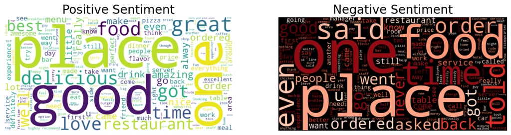

```python
from wordcloud import WordCloud
import matplotlib.pyplot as plt
from nltk.corpus import stopwords
import string

# Define stopwords
stop_words = set(stopwords.words('english') + list(string.punctuation))

# Function to preprocess text
def preprocess_text(text):
    tokens = text.lower().split()
    tokens = [word for word in tokens if word not in stop_words]
    return ' '.join(tokens)

# Filter and preprocess positive reviews
positive_reviews = df[df['stars'] >= 4]['text'].apply(preprocess_text).str.cat(sep=' ')

# Filter and preprocess negative reviews
negative_reviews = df[df['stars'] <= 2]['text'].apply(preprocess_text).str.cat(sep=' ')

# Generate word clouds
positive_wc = WordCloud(width=800, height=400, background_color='white').generate(positive_reviews)
negative_wc = WordCloud(width=800, height=400, background_color='black', colormap='Reds').generate(negative_reviews)

# Plot word clouds
plt.figure(figsize=(15, 7))

# Positive Word Cloud
plt.subplot(1, 2, 1)
plt.imshow(positive_wc, interpolation='bilinear')
plt.axis('off')
plt.title('Positive Sentiment', fontsize=20)

# Negative Word Cloud
plt.subplot(1, 2, 2)
plt.imshow(negative_wc, interpolation='bilinear')
plt.axis('off')
plt.title('Negative Sentiment', fontsize=20)

plt.show()
```

```python
from collections import Counter

# Function to get top words
def get_top_words(text, n=10):
    # Tokenize the preprocessed text
    tokens = text.split()
    # Count word frequencies
    word_counts = Counter(tokens)
    # Get the top 'n' most common words
    return word_counts.most_common(n)

# Get top 10 words for positive reviews
top_positive = get_top_words(positive_reviews, n=10)

# Get top 10 words for negative reviews
top_negative = get_top_words(negative_reviews, n=10)

# Display results
print("Top 10 Positive Sentiment Words:")
for word, count in top_positive:
    print(f"{word}: {count}")

print("\nTop 10 Negative Sentiment Words:")
for word, count in top_negative:
    print(f"{word}: {count}")
```

```
Top 10 Positive Sentiment Words:
great: 6080
food: 4594
place: 4540
good: 4235
get: 3242
like: 3154
one: 3041
really: 2914
also: 2761
would: 2711

Top 10 Negative Sentiment Words:
would: 2085
get: 2056
food: 1976
one: 1923
like: 1849
place: 1547
time: 1491
back: 1394
even: 1380
service: 1376
```